# Another Better Scientific Poster Using R Markdown and pagedown

# Extra Tables & Figures

## Cars are fast

```r
library(dplyr)
library(ggplot2)

  skimr::skim(mtcars) %>%
  select(skim_variable,  numeric.mean, numeric.sd, numeric.p0, numeric.p50, numeric.p100) %>%
  knitr::kable(format = "html")
```

| skim_variable | numeric.mean | numeric.sd | numeric.p0 | numeric.p50 | numeric.p100 |
| --- | --- | --- | --- | --- | --- |
| mpg | 20.090625 | 6.0269481 | 10.400 | 19.200 | 33.900 |
| cyl | 6.187500 | 1.7859216 | 4.000 | 6.000 | 8.000 |
| disp | 230.721875 | 123.9386938 | 71.100 | 196.300 | 472.000 |
| hp | 146.687500 | 68.5628685 | 52.000 | 123.000 | 335.000 |
| drat | 3.596563 | 0.5346787 | 2.760 | 3.695 | 4.930 |
| wt | 3.217250 | 0.9784574 | 1.513 | 3.325 | 5.424 |
| qsec | 17.848750 | 1.7869432 | 14.500 | 17.710 | 22.900 |
| vs | 0.437500 | 0.5040161 | 0.000 | 0.000 | 1.000 |
| am | 0.406250 | 0.4989909 | 0.000 | 0.000 | 1.000 |
| gear | 3.687500 | 0.7378041 | 3.000 | 4.000 | 5.000 |
| carb | 2.812500 | 1.6152000 | 1.000 | 2.000 | 8.000 |

## Diamonds are foreveer

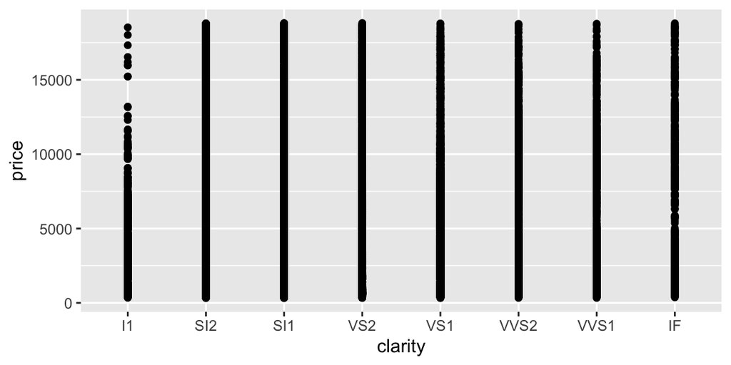

```r
ggplot(diamonds) +
  aes(clarity, price) +
  geom_point()
```

## Starwars has characters

```r
starwars %>%
  mutate(n_films = sapply(films, length)) %>%
  select(name, hair_color, height, species, n_films) %>%
  arrange(desc(n_films)) %>%
  head(10) %>%
  knitr::kable(caption = paste(
    "Characters with most",
    "appearances in Star Wars movies."))
```

Table 1: Characters with most appearances in Star Wars movies.

| name | hair_color | height | species | n_films |
| --- | --- | --- | --- | --- |
| R2-D2 | NA | 96 | Droid | 7 |
| C-3PO | NA | 167 | Droid | 6 |
| Obi-Wan Kenobi | auburn, white | 182 | Human | 6 |
| Luke Skywalker | blond | 172 | Human | 5 |
| Leia Organa | brown | 150 | Human | 5 |
| Chewbacca | brown | 228 | Wookiee | 5 |
| Yoda | white | 66 | Yoda’s species | 5 |
| Palpatine | grey | 170 | Human | 5 |
| Darth Vader | none | 202 | Human | 4 |
| Han Solo | brown | 180 | Human | 4 |

## Heavy cars are inefficient

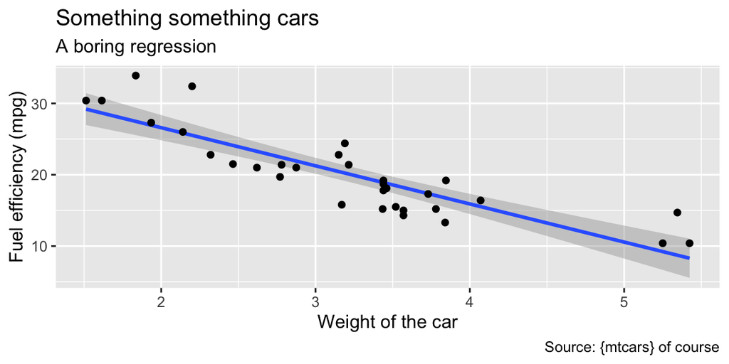

```r
ggplot(mtcars) +
  aes(wt, mpg) +
  geom_smooth(method = "lm") +
  geom_point() +
  labs(title = "Something something cars",
       subtitle = "A boring regression",
       caption = "Source: {mtcars} of course",
       x = "Weight of the car",
       y = "Fuel efficiency (mpg)")
```

# References

Fenner, Martin. 2012. “One-Click Science Marketing.” *Nature Materials* 11 (4): 261–63. https://doi.org/10.1038/nmat3283.